## Functions 0

```
library(tidyverse)
```

### 1. Creating functions

```r
pow <- function(x, p) {
  power <- x ^ p
  return(power)
}
pow(3, 2)
```

```
## [1] 9
```

If there is no `return()`, the last computed value is returned:

```r
pow <- function(x, p) {
  x ^ p
}
pow(3, 2)
```

```
## [1] 9
```

What is the problem here?

```r
pow <- function(x, p) {
  power <- x ^ p
}
pow(3, 2)
```

If the function is short, you don’t have to use {}:

```r
pow <- function(x, p) x ^ p
pow(3, 2)
```

```
## [1] 9
```

Default parameters:

```r
pow <- function(x, p = 2) x ^ p
pow(3)
```

```
## [1] 9
```

```r
pow(3, 3)
```

```
## [1] 27
```

Lazy evaluations:

R is a procrastinator, it reads the the data only when it needs it for computation purposes, this means that there won’t be an error if we execute the following piece of code:

```r
pow <- function(x, p = 2, we_will_not_use_this_parameter) x ^ p
pow(x = 3)
```

```
## [1] 9
```

### 2. Adequacy (sanity check)

We need to make sure that our functions don’t produce results for inadequate entry data. For instance, to avoid situations [like that](https://genomebiology.biomedcentral.com/articles/10.1186/s13059-016-1044-7).

What does `imt()` do?

```r
imt <- function(weight, height) weight / height ^ 2
```

Testing the function:

```r
w <- c(60, 80, 120)
h <- c(1.6, 1.7, 1.8)
imt(weight = w, height = h)
```

```
## [1] 23.43750 27.68166 37.03704
```

Do you foresee any problems with the use of this function?

```r
imt <- function(weight, height) {
  if (any(height > 3)) warning("The height value is bigger than 3: perhaps, the height value is in cm, not in m (as required)!\n")
  weight / height ^ 2
}
imt(52, 167)
```

```
## [1] 0.001864534
```

What about zero values for weight and height?

```r
imt <- function(weight, height) {
  if (any(weight <= 0 | height <= 0)) stop("Body mass index cannot be computed for negative or zero values")
  if (any(height > 3)) warning("The height value is bigger than 3: perhaps, the height value is in cm, not in m (as required)!\n")
  weight / height ^ 2
}
```

[Please look at the debugging techniques](https://adv-r.hadley.nz/debugging.html)

### 3. When and why do we need functions?

- Rule of three
- not to repeat the same
- a way of abstraction

### 4. Functions as objects of the first order

- Almost eveything in R is a function, even {
- Functions are objects of the first order, which means that you do with functions many things that you can do with vectors, dataframes etc.:

```r
list(mean, min, `{`)
```

```
## [[1]]
## function (x, ...)
## UseMethod("mean")
## <bytecode: 0x559d414cefc8>
## <environment: namespace:base>
##
## [[2]]
## function (..., na.rm = FALSE)  .Primitive("min")
##
## [[3]]
## .Primitive("{")
```

- Recursion: we can use functions are arguments for other functions, we can save functions as variables
- The same will be true of Python as well (barring the syntactic conventions)

### 5. The family of `apply()` functions

- Working with a matrix

```r
A <- matrix(1:12, 3, 4)
A
```

```
##      [,1] [,2] [,3] [,4]
## [1,]    1    4    7   10
## [2,]    2    5    8   11
## [3,]    3    6    9   12
```

The syntax: `apply(X, MARGIN, FUN, ...)`, where X — the data, MARGIN is 1 (for rows), 2 (for columns), c(1,2) for rows and columns (= for each element), and FUN — a function that you would like to apply

```r
apply(A, 1, sum) #sum for every row #note that a function apply applies to a function sum
```

```
## [1] 22 26 30
```

```r
apply(A, 2, sum) #sum for every column
```

```
## [1]  6 15 24 33
```

```r
apply(A, c(1,2), sum) #sum of every element -- does not make much sense
```

```
##      [,1] [,2] [,3] [,4]
## [1,]    1    4    7   10
## [2,]    2    5    8   11
## [3,]    3    6    9   12
```

Additional arguments can be listed:

```r
apply(A, 1, sum, na.rm = TRUE)
```

```
## [1] 22 26 30
```

```r
apply(A, 1, weighted.mean, w = c(0.2, 0.4, 0.3, 0.1))
```

```
## [1] 4.9 5.9 6.9
```

- Anonymous functions

Functions that are used one time and do not have a name

```r
apply(A, 1, function(x) sum((x - mean(x))^2)) #sd from the mean by row
```

```
## [1] 45 45 45
```

```r
apply(A, 2, function(x) sum((x - mean(x))^2)) #sd from the mean by column
```

```
## [1] 2 2 2 2
```

```r
apply(A, c(1, 2), function(x) sum((x - mean(x))^2)) #diviation from each value, i.e., zero
```

```
##      [,1] [,2] [,3] [,4]
## [1,]    0    0    0    0
## [2,]    0    0    0    0
## [3,]    0    0    0    0
```

```r
apply(A, 1, function(whatevername) sum((whatevername - mean(whatevername))^2)) #you can name the variable in any way you want
```

```
## [1] 45 45 45
```

- Other functions of the family
  - `lapply` – apply to every element of a list

```r
some_list <- list(some = 1:10, list = letters)
lapply(some_list, length)
```

```
## $some
## [1] 10
##
## $list
## [1] 26
```

- `sapply()` - a version of `lapply()` that tries to return the result in a vector or a matrix

```r
sapply(some_list, length)
```

```
## some list
##   10   26
```

- applying `sapply()` to a vector:

```r
sapply(1:10, sqrt)
```

```
##  [1] 1.000000 1.414214 1.732051 2.000000 2.236068 2.449490 2.645751 2.828427
##  [9] 3.000000 3.162278
```

```r
sqrt(1:10)
```

```
##  [1] 1.000000 1.414214 1.732051 2.000000 2.236068 2.449490 2.645751 2.828427
##  [9] 3.000000 3.162278
```

- we can use `lapply()` and `sapply()` for dataframes, because a dataframe is basically a list of vectors of the same length, the functions will iterate through columns:

```r
heroes <- read.csv("https://raw.githubusercontent.com/dashapopova/Intro-to-R/main/HWs/heroes_information.csv",
                   na.strings = c("-", "-99"))
sapply(heroes, class)
```

```
##           X        name      Gender   Eye.color        Race  Hair.color
##   "integer" "character" "character" "character" "character" "character"
##      Height   Publisher  Skin.color   Alignment      Weight
##   "numeric" "character" "character" "character"   "integer"
```

- replicate() – to replicate an operation

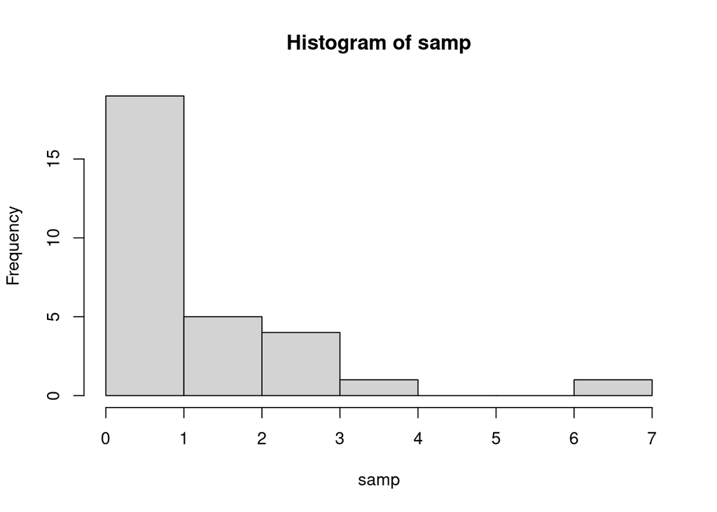

```r
samp <- rlnorm(30)
hist(samp)
```

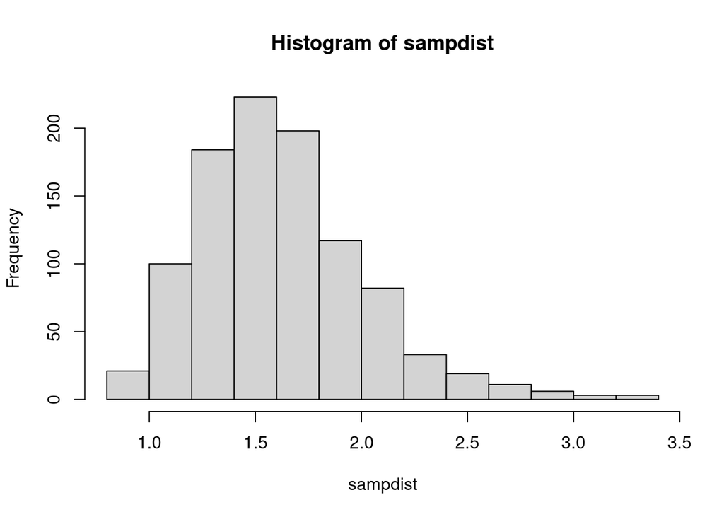

```r
sampdist <- replicate(1000, mean(rlnorm(30)))
hist(sampdist)
```

[A tutorial](https://www.datacamp.com/community/tutorials/r-tutorial-apply-family)